# Escuela Familia, parentesco y hogares en América Latina y el Caribe

XI Congreso de la Asociación Latinoamericana de Población (ALAP); Bogotá, Diciembre 10, 2024

Instructors: Amanda Martins de Almeida, Liliana P. Calderon-Bernal, Ivan Williams & Diego Alburez-Gutierrez

Updated: 2024-12-10

## Preparación

Instale los siguientes paquetes en R antes de iniciar con el laboratorio:

```r
install.packages("tidyverse")
install.packages("data.table")
install.packages("ggh4x")
install.packages("devtools")
devtools::install_github("MPIDR/rsocsim", ref = "v1.5.9")
devtools::install_github("IvanWilli/DemoKin")
```

## Introducción

#### Descripción del curso:

El parentesco es una propiedad fundamental de las poblaciones humanas y una forma clave de estructura social. Los demógrafos llevan mucho tiempo interesados en la interacción entre el cambio demográfico y la configuración familiar. Esto ha llevado al desarrollo de sofisticados enfoques metodológicos y conceptuales para el estudio del parentesco, algunos de los cuales se revisan en este curso.

Algunas cosas útiles que hay que saber:

- Las diapositivas del curso están disponibles aquí: https://github.com/amandamartinsal/ALAP24_parentesco/tree/master/slides
- Encuentre el código fuente de este sitio web en GitHub: https://github.com/amandamartinsal/ALAP24_parentesco

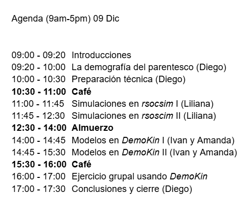

[figure not shown]

## rsocsim

- Introducción
- Cómo configurar, correr y verificar una microsimulación en R?
- ¿Qué se puede hacer con los resultados de la simulación?
- Más información

NB: Este tutorial incluye las explicaciones y el código que se presentarán oralmente durante la escuela. Puedes consultarlo con antelación, pero no es pre-requisito.

#### Introducción: ¿Qué es SOCSIM y cómo funciona?

SOCSIM se desarrolló originalmente para Unix en UC Berkeley (E. Hammel et al. 1976), donde se ha mantenido durante décadas. La versión actual de rsocsim pretende ser independiente del sistema operativo y, en su mayor parte, compatible con la distribución original de SOCSIM. Para más información sobre el SOCSIM original, véase https://lab.demog.berkeley.edu/socsim/ y especialmente Mason (2016).

La siguiente descripción de SOCSIM se ha adaptado de los materiales complementarios de Alburez‐Gutierrez, Mason, and Zagheni (2021). SOCSIM es un programa de microsimulación demográfica de código abierto y extensible. Está escrito en el lenguaje de programación C y se basa en gran medida en matrices de listas enlazadas para hacer seguimiento de las relaciones de parentesco y almacenar información sobre los individuos simulados. El simulador toma como datos de entrada los archivos iniciales de población y las tasas demográficas mensuales de fecundidad y mortalidad por edades. El individuo es la unidad de análisis del simulador. Cada persona está sujeta a un conjunto de tasas, expresadas como probabilidades mensuales de eventos, dadas ciertas características demográficas, como la edad y el sexo. Cada mes, cada individuo se enfrenta al riesgo de experimentar una serie de eventos, como el nacimiento, la muerte y el matrimonio. La selección del evento y el tiempo de espera hasta que se produzca se determinan estocásticamente mediante un modelo de riesgo competitivo. En el programa de simulación se incluyen algunas otras restricciones con el fin de sortear los eventos sólo para los individuos que reúnen las condiciones para ser elegibles (por ejemplo, para permitir un intervalo mínimo de tiempo entre nacimientos de la misma madre, para evitar tabúes sociales como el incesto, etc.). Cada evento para el cual el individuo está en riesgo se modela como una distribución exponencial por partes. El tiempo de espera hasta que se produzca cada evento se genera aleatoriamente en función de las tasas demográficas asociadas. El siguiente evento a ser ejecutado para cada individuo es aquel con el tiempo de espera más corto.

Al final de la simulación, se crean archivos de población que contienen una lista de todas las personas que han vivido alguna vez en la población. En estos archivos, cada individuo es una observación en un archivo de datos rectangular con que registra las características demográficas del individuo y los números de identificación de las principales relaciones de parentesco. SOCSIM modela poblaciones «cerradas», es decir, los individuos sólo pueden entrar y salir de la simulación por nacimiento y muerte (simulados).

SOCSIM se ha utilizado ampliamente en la investigación en ciencias sociales para estudiar, entre otras cosas, la dinámica de la disponibilidad de parientes (E. A. Hammel 2005; Kenneth W. Wachter 1997; Verdery and Margolis 2017), la superposición generacional (Margolis and Verdery 2019; Alburez‐Gutierrez, Mason, and Zagheni 2021) y la pérdida de parientes (Zagheni 2011; Verdery et al. 2020; Snyder et al. 2022).

#### 1. Configuración

Si quieres instalar `rsocsim` en tu computador, te recomendamos revisar el punto 1 de este tutorial antes de comenzar la escuela. Si tienes alguna pregunta/dificultad, por favor, ponte en contacto con el coordinador del taller (Diego Alburez).

[figure not shown]

##### 1.1. Instalación

Instala la versión en desarrollo de `rsocsim` desde GitHub (https://github.com/MPIDR/rsocsim). Es posible que hayamos realizado cambios en el paquete `rsocsim` antes de este taller. Para estar seguro, si ya habías instalado el paquete, desinstálalo y vuelve a instalarlo.

```r
# remove.packages("rsocsim")
# install.packages("devtools")
remotes::install_github("MPIDR/rsocsim", ref='v1.5.9')
```

Veámos si todo funciona correctamente. `rsocsim` tiene una simulación sencilla incorporada que puedes ejecutar para ver si el paquete se ha instalado correctamente. Por ahora, vamos a ejecutar el código sin centrarnos en los detalles técnicos:

```r
library(rsocsim)

# Crea una nueva carpeta para todos los archivos relacionados con la simulación.
# Esta estará en tu directorio de inicio o de usuario:
folder = rsocsim::create_simulation_folder()

# Crea un nuevo archivo de supervisión.
# Los archivos de supervisión le dicen a socsim qué simular.
# create_sup_file() creará un archivo de supervisión muy básico
# y copiará algunos archivos de tasas que serán necesarios en la carpeta de simulación:
supfile = rsocsim::create_sup_file(folder)

# Elige una semilla aleatoria:
seed = 300

# Inicia la simulación:
rsocsim::socsim(folder, supfile, seed)
```

[output not shown]

```
## [1] 1
```

Para más información sobre el paquete, el microsimulador SOCSIM, su historia y sus aplicaciones, consulte el sitio web de `rsocsim`: https://mpidr.github.io/rsocsim/.

##### 1.2. Instala otros paquetes

Necesitaremos estos otros paquetes para este taller. Si no los tienes aún, por favor, instálalos:

```r
# devtools::install_github("MPIDR/rsocsim")
library(rsocsim)
# install.packages("tidyverse")
library(tidyverse) # Para la gestión de datos
# install.packages("ggh4x")
library(ggh4x) # Para graficar con facetas
# install.packages("data.table") # Para grandes conjuntos de datos
library(data.table)
```

#### 2. ¿Cómo configurar, correr y verificar una microsimulación en R?

Objetivos

1. Utilizar datos del World Population Prospects (WPP) 2024 para crear una simulación desde cero
2. Ejecutar una simulación SOCSIM simple para Colombia
3. Estimar las tasas de fecundidad y mortalidad por edad resultantes usando los microdatos generados por SOCSIM
4. Comprobar que las tasas SOCSIM ‘de salida’ coinciden con las tasas WPP ‘de entrada’

##### 2.1. La simulación: archivos de supervisión y archivos de tasas

Para dar un ejemplo de la utilización de `rsocsim`, realizaremos una microsimulación SOCSIM para Colombia para el periodo 1950-2023. Esta microsimulación utiliza como insumos: tasas específicas de fecundidad por edad simple y año calendario y probabilidades de muerte por edad simple, sexo y año calendario descargadas de las [Perspectivas de la Población Mundial 2024](https://population.un.org/wpp/) (en adelante, WPP 2024, por sus siglas en inglés) .

Para correr la simulación, los datos originales de WPP deben convertirse primero a tasas o probabilidades mensuales en formato SOCSIM, tal y como se describe en SOCSIM Oversimplified (c.f. Mason 2016 para más detalles). Las tasas correspondientes a cada año se especifican en el archivo de supervisión `socsim_Colombia.sup`, proporcionado en este repositorio, que se utilizará para ejecutar la simulación. El primer segmento de la simulación se ejecuta durante 100 años (1200 meses) para producir una estructura por edades estable, basada en las tasas y probabilidades de WPP para 1950. Cada uno de los segmentos siguientes se ejecuta durante un año (12 meses) con los archivos de fecundidad y mortalidad correspondientes.

##### 2.2. Escribir los archivos de tasas de entrada para una simulación SOCSIM para Colombia, 1950-2023

La estructura de los archivos de tasas es esencial para correr SOCSIM. Según SOCSIM Oversimplified (c.f. Mason 2016, 26–28), un bloque de tasas es un conjunto completo de tasas especíﬁcas por edad que rigen un evento demográfico para personas de un sexo, grupo y estado civil determinados. En los archivos de tasas, el orden es siempre evento demográfico (birth, death, marriage), grupo (1, ..), sexo (F o M) y estado civil (married, single, divorced, widowed). Para las tasas de fecundidad, puede ir seguido de un número que indique la paridad. Cada línea posterior contiene una tasa o probabilidad mensual y el intervalo de edad sobre el que rige (años y meses del límite superior de edad). El intervalo incluye el límite superior de edad de la línea anterior y termina justo antes del límite superior de edad de la línea actual. Los dos primeros números son los años y meses del límite superior de edad, que se suman; por ejemplo, un límite superior de edad de “1 0” or “0 12” se refiere al primer año de vida [0,1).

Carguemos algunas funciones que hemos preparado para escribir los archivos de tasas SOCSIM a partir de los datos de WPP 2024.

```r
# Cargar funciones para escribir archivos de tasas SOCSIM
source("functions_rates.R")
```

###### 2.2.1. Archivos de fecundidad para SOCSIM

Como datos de entrada de fecundidad, utilizamos todo el rango de edades de la tasas de fecundidad por edad simple de la madre proporcionada por WPP 2024 [15-49]. Los grupos de edad más jóvenes [10-14] y mayores [50-54] sólo se proporcionan en las estimaciones por grupos de edad de 5 años. Adicionalmente, SOCSIM requiere una categoría de edad final con un límite superior correspondiente a la duración máxima de la vida. Aquí, la fijamos a [50-100], para ser coherentes con la estructura de las tablas de mortalidad de WPP.

Para convertir las tasas anuales en mensuales, suponemos que las tasas de fecundidad son constantes a lo largo del año y las dividimos por 12 (meses). Según SOCSIM oversimplified, se trata de tasas y no de probabilidades. Por tanto, al multiplicar una tasa por el número de meses de la categoría de edad se obtiene el número esperado de nacimientos que experimentará una mujer que viva esa categoría de edad.

En este ejercicio, las tasas son idénticas para todos los estados civiles. Sin embargo, en los archivos de tasas se deben especificar al menos para las mujeres solteras y casadas (single, married). Los demás estados civiles (divorced, widow, cohabiting) siguen las reglas predeterminadas para las tasas en SOCSIM.

Para este ejercicio, utilizaremos las tasas específicas de fecundidad por edad para todos los órdenes de nacimiento por año calendario y edad simple de la madre para un país seleccionado de WPP 2024. Los datos descargados de la página web del WPP 2024, filtrados para un país y conservando sólo las variables relevantes, se proporcionan en `data/fertility_Colombia.RData`. Si deseas ejecutar el análisis para otro territorio, puedes utilizar la función `UNWPP_data()` y seleccionar una ubicación, ISO2_code o ISO3_code diferente para filtrar los datos del WPP 2024.

La siguiente función convierte al formato SOCSIM los datos de fecundidad de WPP 2024 (filtrados para un país usando `UNWPP_data()`) siguiendo el procedimiento explicado anteriormente. Para ejecutarla, escribe el nombre del país (región, subregión o zona) tal como figura en WPP 2024 (por ejemplo, “Colombia”). Por favor, asegúrate de que el archivo con los datos de fecundidad de WPP filtrado para dicho país se encuentre en la carpeta `data`.

```r
write_socsim_fertility_rates_WPP(country = "Colombia")
```

###### 2.2.2. Archivos de mortalidad para SOCSIM

Como datos de entrada de mortalidad, SOCSIM requiere probabilidades de muerte (qx) de las tablas de mortalidad de periodo. Utilizamos todo el rango de edades de las tablas de mortalidad por edad simple proporcionadas por WPP 2024 [0-100]. El intervalo final de edad “100” se limita a un año, es decir, [100-101). Originalmente, SOCSIM tenía un límite superior de 100 años, pero en `rsocsim` la edad máxima se ha ampliado a 200 años, en caso de que los datos de mortalidad superen el límite de 100.

Para convertir las probabilidades de muerte anuales de WPP en probabilidades mensuales “SOCSIM”, suponemos que la probabilidad de morir es constante a lo largo del año y utilizamos la fórmula $1-(1-_nq_x)^{1/n}$ propuesta por Kenneth Watcher (Kenneth W. Wachter 2014, 53). Para el intervalo final de edad 100, las probabilidades mensuales son iguales a 1/12. Las probabilidades de muerte son idénticas para todos los estados civiles de cada sexo. Sin embargo, para este ejercicio sólo se especifican para mujeres solteras y hombres solteros (single) en los archivos de tasas. Los demás estados civiles seguirán las reglas predeterminadas para las tasas en SOCSIM.

Los métodos utilizados para estimar la mortalidad y las tablas de mortalidad en WPP 2024 varían de un país a otro, dependiendo del tipo y la calidad de los datos empíricos disponibles. Para más detalles, véase la Metodología de las estimaciones y proyecciones de población de las Naciones Unidas (United Nations and Social Affairs 2024).

Para este ejercicio, utilizaremos las probabilidades de muerte (qx) por año calendario, sexo y edad simple para un país seleccionado de WPP 2024. Proporcionamos los datos descargados de la página web del WPP 2024 para mujeres y hombres, filtrados para un país y conservando sólo las variables relevantes (disponibles en `data/mortality_Colombia.RData`). Si desea sejecutar el análisis para otro territorio, puede utilizar la funcion `UNWPP_data()` y seleccionar una ubicación, ISO2_code o ISO3_code diferente para filtrar los datos de WPP 2024.

La siguiente función convierte al formato SOCSIM los datos de mortalidad de WPP 2024 (filtrados para un país usando `UNWPP_data()`), siguiendo el procedimiento explicado anteriormente. Para ejecutarla, escribe el nombre del país (región, subregión o área) tal como aparece en WPP 2024 (por ejemplo, “Colombia”). Por favor, asegúrate de que el archivo con los datos de mortalidad de WPP para dicho país se encuentre en la carpeta `data`.

```r
write_socsim_mortality_rates_WPP(country = "Colombia")
```

##### 2.3. Crear los archivos iniciales de población y matrimonios

Ahora que tenemos los archivos de tasas, vamos a crear los archivos iniciales de población (.opop) y matrimonio (.opop). Por cuestiones prácticas del taller, usaremos una población inicial pequeña para reducir el tiempo de ejecución de la simulación y de cómputo del código posterior. El archivo .opop inicial tendrá un tamaño de 1000, con sexo y fechas de nacimiento asignados aleatoriamente, y grupo 1 para todos. Las demás columnas se completarán durante la simulación. El archivo .omar inicial será un archivo vacío.

```r
# Definir una semilla para tener los mismos resultados (solo para este taller)
set.seed(101224)

# Establecer el tamaño de la población inicial
size_opop <-  1000

# Crear data.frame con 14 columnas y n filas igual a la población inicial
presim.opop <- setNames(data.frame(matrix(data = 0, ncol = 14, nrow = size_opop)),
                        c("pid","fem","group","nev","dob","mom","pop",
                          "nesibm","nesibp","lborn","marid","mstat","dod","fmult"))

# Añadir pid 1:sizeopop
presim.opop$pid <- 1:size_opop

# Añadir sexo aleatoriamente
presim.opop$fem <- sample(0:1, nrow(presim.opop), replace = T)

# Añadir el grupo 1 para todos los individuos
presim.opop$group <- 1

# Añadir fechas de nacimiento aleatorias
presim.opop$dob <- sample(500:1000, nrow(presim.opop), replace = T)

# Guardar la población inicial para la presimulación
write.table(presim.opop, "presim.opop", row.names = F, col.names = F)

# Crear un data frame vacío para los matrimonios en la población inicial
presim.omar <- data.frame()

# Guardar el archivo omar de la población inicial
write.table(presim.omar, "presim.omar", row.names = F, col.names = F)
```

##### 2.4. Correr una simulación SOCSIM con el paquete `rsocsim`

Una vez creados los archivos de tasas de entrada y los archivos iniciales de población y matrimonios, podemos ejecutar la simulación. Para utilizar la función `socsim`, debemos especificar la carpeta en la que se encuentran los archivos de supervisión y de tasas, el nombre del archivo de supervisión para las tasas recuperadas del WPP 2024 (1950-2023) y un número de semilla para la simulación.

```r
# Especifica la carpeta donde se encuentran los archivos de supervisión y de tasas.
# Si la sesión de R se está ejecutando a través del proyecto, puedes utilizar el siguiente comando.
folder <- getwd()

# Escribe el nombre del archivo de supervisión almacenado en la carpeta anterior:
supfile <- "socsim_Colombia.sup"

# Elige un número semilla (fecha de hoy) para la simulación:
seed <- "101224"

# Correr una simulación SOCSIM con la carpeta y el archivo de supervisión proporcionado,
# utilizando el método de proceso futuro
rsocsim::socsim(folder, supfile, seed, process_method = "future")
```

Los resultados de la simulación están listos. Podemos utilizar las funciones `read_opop` y `read_omar` del paquete `rsocsim`para importar los archivos de población y matrimonio de salida a `R`.

```r
## Leer el archivo opop usando la función read_opop()
opop <- rsocsim::read_opop(folder = getwd(), supfile = "socsim_Colombia.sup",
                           seed = "101224", suffix = "", fn = NULL)
```

```
## [1] "read population file: C:/Users/martins/Desktop/ALAP24_parentesco/docs/sim_results_socsim_Colombia.sup_101224_/result.opop"
```

```r
## Leer el archivo omar usando la función read_omar()
omar <- rsocsim::read_omar(folder = getwd(), supfile = "socsim_Colombia.sup",
                           seed = "101224", suffix = "",  fn = NULL)
```

```
## [1] "read marriage file: C:/Users/martins/Desktop/ALAP24_parentesco/docs/sim_results_socsim_Colombia.sup_101224_/result.omar"
```

Demos un vistazo a los archivos de población y matrimonio.

El archivo de población (.opop) contiene un registro por cada individuo que ha estado vivo durante la simulación. Cada registro (fila) proporciona la siguiente información sobre un individuo determinado: identificador de persona (pid), sexo (fem, 1 para mujer y 0 para hombre), identificador de grupo (group), siguiente evento programado (nev), fecha de nacimiento (dob), identificador de persona de la madre (mom), identificador de persona del padre (pop), identificador de persona del siguiente hermano mayor por vía materna (nesibm), identificador de persona del siguiente hermano mayor por vía paterna (nesibp), identificador de persona del último hijo nacido (lborn), identificador del matrimonio más reciente en .omar (marid), estado civil al final de la simulación (mstat), fecha de defunción (dod, o 0 si está vivo al final de la simulación) y multiplicador de fertilidad (fmult). Para más información sobre lo que significan estas columnas, consulta: https://lab.demog.berkeley.edu/socsim/CurrentDocs/socsimOversimplified.pdf.

```r
head(opop)
```

```
##   pid fem group nev dob mom pop nesibm nesibp lborn marid mstat  dod    fmult
## 1   1   1     1  65 609   0   0      0      0     0     0     1 1640 0.721646
## 2   2   0     1  65 930   0   0      0      0     0     0     1 1201 0.000000
## 3   3   1     1  65 591   0   0      0      0  1435    33     3 1629 1.057861
## 4   4   0     1  65 502   0   0      0      0  1383   243     4 1158 0.000000
## 5   5   1     1  65 791   0   0      0      0  2543   375     3 1796 1.400603
## 6   6   1     1  65 636   0   0      0      0  1207   170     3 1540 0.235570
```

El archivo de matrimonios (.omar) contiene un registro por cada matrimonio ocurrido durante la simulación. Cada registro de matrimonio proporciona la siguiente información: número identificador del matrimonio (mid), identificador de persona de la esposa (wpid), identificador de persona del esposo (hpid), fecha de inicio del matrimonio (dstart), fecha de finalización del matrimonio (dend, es 0 si estaba vigente al final de la simulación), razón por la que finalizó el matrimonio (rend), identificador del siguiente matrimonio anterior más reciente de la esposa (wprior), identificador del siguiente matrimonio anterior más reciente del esposo (hprior).

```r
head(omar)
```

```
##   mid wpid hpid dstart dend rend wprior hprior
## 1   1  158  467   1001 1167    3      0      0
## 2   2  879  409   1001 1029    3      0      0
## 3   3  710  374   1001 1053    3      0      0
## 4   4  199  247   1001 1336    3      0      0
## 5   5  650  196   1001 1255    3      0      0
## 6   6  766  856   1001 1466    3      0      0
```

##### 2.5. Estimar las tasas específicas por edad a partir de los resultados de la microsimulación SOCSIM

Para comprobar la precisión de nuestra microsimulación para Colombia, podemos estimar y comparar las tasas de entrada y de salida de fecundidad y mortalidad específicas por edad y sexo. Para ello, podemos utilizar las funciones `estimate_fertility_rates()` y `estimate_mortality_rates()` del paquete. Ten en cuenta que estas funciones calculan tasas específicas por edad tanto para la fecundidad como para la mortalidad, ya que utilizan el tamaño de la población a mitad de año por sexo y edad como una estimación de los años-persona vividos durante el año. Por lo tanto, la población del denominador incluye a todos aquellos que nacieron antes del 1 de julio de un año determinado y mueren en julio de ese año o después, o siguen vivos al final de la simulación. Debido al tamaño limitado de la población en una microsimulación (especialmente, de supervivientes a edades avanzadas), a veces pocos o ningún individuo de una edad específica están vivos en un momento determinado (aquí, el 1 de julio). Por ello, con estas funciones es posible obtener tasas superiores a 1, iguales a 0 (0 eventos/población), infinitas (eventos/0 población) y valores NaN (0 eventos/0 población).

Para ejecutar las funciones, necesitamos definir algunos argumentos: el archivo .opop `opop`, el año final de la simulación `final_sim_year`, los años mínimo y máximo para los que queremos estimar las tasas, [`year_min` y `year_max`), el tamaño del grupo de años `year_group`, la edad mínima y máxima para la fecundidad [`age_min_fert` y `age_max_fert`) o la edad máxima para la mortalidad `age_max_mort`) y el tamaño del grupo de edades `age_group`. Podemos calcular las tasas para diferentes años y grupos de edad (por ejemplo, 1, 5 o 10), pero es importante que los años y edades mínimos y máximos correspondan con el tamaño de los grupos. Puedes leer la documentación completa de estas funciones escribiendo `?estimate_fertility_rates` o `?estimate_mortality_rates` en la consola de RStudio. Ejecutemos el código.

```r
# Estimar las tasas de fecundidad por edad
asfr_sim <- rsocsim::estimate_fertility_rates(opop = opop,
                                              final_sim_year = 2023, #[Ene-Dic]
                                              year_min = 1950, # Cerrado [
                                              year_max = 2020, # Abierto )
                                              year_group = 5,
                                              age_min_fert = 15, # Cerrado [
                                              age_max_fert = 50, # Abierto )
                                              age_group = 5) # [,)

# Estimar las tasas de mortalidad por edad
asmr_sim <- rsocsim::estimate_mortality_rates(opop = opop,
                                              final_sim_year = 2023, # [Ene-Dic]
                                              year_min = 1950, # Cerrado
                                              year_max = 2020, # Abierto )
                                              year_group = 5,
                                              age_max_mort = 100, # Abierto )
                                              age_group = 5) #[,)
```

Ahora podemos graficar nuestras estimaciones de fecundidad y mortalidad derivadas de la microsimulación para mujeres en algunos años seleccionados.

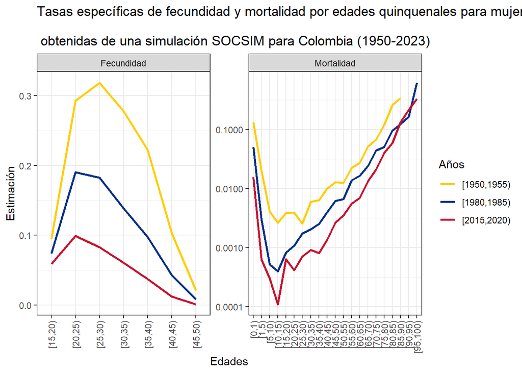

```r
# Elige los años a graficar (en intervalos).
yrs_plot <- c("[1950,1955)", "[1980,1985)", "[2015,2020)")

# Obtén los niveles de edad para definirlos antes de graficar y evitar un orden erróneo
age_levels <- levels(asmr_sim$age)

bind_rows(asfr_sim %>%
            mutate(rate = "Fecundidad",
                   sex = "female"),
          asmr_sim %>%
            mutate(rate = "Mortalidad") %>%
            filter(sex == "female")) %>%
  mutate(age = factor(as.character(age), levels = age_levels)) %>%
  # Filtrar las tasas de valores 0, infinitos (N_Muertes/0_Población) y NaN (0_Muertes/0_Población)
  filter(socsim !=0 & !is.infinite(socsim) & !is.nan(socsim)) %>%
  filter(year %in% yrs_plot) %>%
  ggplot(aes(x = age, y = socsim, group = year, colour = year)) +
  geom_line(linewidth = 1) +
  facet_wrap(. ~ rate, scales = "free") +
  facetted_pos_scales(y = list(ASFR = scale_y_continuous(),
                               ASMR =  scale_y_continuous(trans = "log10"))) +
  scale_x_discrete(guide = guide_axis(angle = 90)) +
  scale_color_manual(values = c("#FFCD00", "#003087", "#C8102E"))+
  labs(title = "Tasas específicas de fecundidad y mortalidad por edades quinquenales para mujeres
       \n obtenidas de una simulación SOCSIM para Colombia (1950-2023)",
       x = "Edades", y = "Estimación", color = "Años") +
    theme_bw()
```

##### 2.6. Comparar las tasas específicas por edad SOCSIM vs WPP 2024

Como verificación adicional, podemos comparar las tasas específicas de fecundidad y mortalidad por edad obtenidas a partir de los resultados de SOCSIM con los datos originales WPP utilizados como entrada para nuestra microsimulación. Dado que nuestras estimaciones de las tasas de fecundidad y mortalidad a partir de los resultados de SOCSIM se agrupan por grupos de edades quinquenales y periodos de 5 años en el ejemplo anterior, debemos estimar primero las tasas agregadas (5x5) a partir de los datos originales de WPP 2024. Para graficar los datos conjuntamente, también necesitamos reorganizarlos.

Empecemos con las estimaciones de fecundidad.

```r
# Extraer los intervalos de año y edad utilizados en estimate_fertility_rates()
# para aplicar los mismos valores a los datos de WPP.
# Extraer todos los valores únicos de los intervalos de años
year_breaks_fert <- unique(as.numeric(str_extract_all(asfr_sim$year, "\\d+", simplify = T)))

# Rango de años para filtrar los datos WPP
year_range_fert <- min(year_breaks_fert):max(year_breaks_fert-1)

# Extraer todos los valores únicos de los intervalos de edad
age_breaks_fert <- unique(as.numeric(str_extract_all(asfr_sim$age, "\\d+", simplify = T)))

# Cargar los datos de fecundidad WPP utilizados para escribir las tasas de entrada y
# recalcular las tasas específicas de fecundidad por grupos quinquenales de edad.
load("data/fertility_Colombia.RData")

WPP_fert <- fertility_Colombia %>%
  filter(year %in% year_range_fert) %>%
  mutate(year = cut(year, breaks = year_breaks_fert,
                    include.lowest = F, right = F, ordered_results = T),
         age = cut(age, breaks = age_breaks_fert,
                   include.lowest = F, right = F, ordered_results = T)) %>%
  filter(!is.na(age)) %>%
  group_by(year, age) %>%
  summarise(ASFR = mean(fx, na.rm = T)) %>%
  ungroup() %>%
  mutate(Source = "WPP",
         Rate = "Fecundidad")

# Organizar las estimaciones de fecundidad de SOCSIM
SocsimF <- asfr_sim %>%
  rename(ASFR = socsim) %>%
  mutate(Source = "SOCSIM",
         Rate = "Fecundidad")
```

Ahora, evaluaremos las estimaciones de mortalidad. Aquí, comparamos las tasas específicas de mortalidad por edad a mitad de año de SOCSIM con las tasas centrales de mortalidad de las tablas de mortalidad de WPP.

```r
# Extraer los intervalos de año y edad utilizadas en estimate_mortality_rates() para aplicarlos a los datos WPP.

# Extraer todos los valores únicos de los intervalos de años
year_breaks_mort <- unique(as.numeric(str_extract_all(asmr_sim$year, "\\d+", simplify = T)))

# Rango de años para filtrar los datos WPP
year_range_mort <- min(year_breaks_mort):max(year_breaks_mort-1)

# Extraer todos los valores únicos de los intervalos de edad
age_breaks_mort <- unique(as.numeric(str_extract_all(asmr_sim$age, "\\d+", simplify = T)))

# Cargar los datos de mortalidad WPP y recalcular las tasas de mortalidad por grupos quinquenales de edad.
# Para facilitar la comparacion, usaremos las tasas centrales de mortalidad (mx) y no las probabilidades (QX)
load("data/mortality_Colombia.RData")

# Organizar las tablas de mortalidad WPP
WPP_mort <- mortality_Colombia %>%
  select(year, Sex, age, mx) %>%
  filter(year %in% year_range_mort) %>%
  mutate(year = cut(year, breaks = year_breaks_mort,
                    include.lowest = F, right = F, ordered_results = T),
         age = cut(age, breaks = age_breaks_mort,
                   include.lowest = F, right = F, ordered_results = T)) %>%
  filter(!is.na(age)) %>%
  group_by(year, Sex, age) %>%
  summarise(mx = mean(mx, na.rm = T)) %>%
  ungroup() %>%
    mutate(Source = "WPP",
           Rate = "Mortalidad")

# Organizar las estimaciones de mortalidad de SOCSIM
SocsimM <- asmr_sim %>%
  rename(mx = socsim) %>%
  mutate(Sex = ifelse(sex == "male", "Male", "Female"),
         Source = "SOCSIM",
         Rate = "Mortalidad") %>%
  select(year, Sex, age,  mx, Source, Rate)
```

Finalmente, podemos graficar las tasas de fecundidad y mortalidad por edad para mujeres en Colombia obtenidas de los resultados SOCSIM y de WPP.

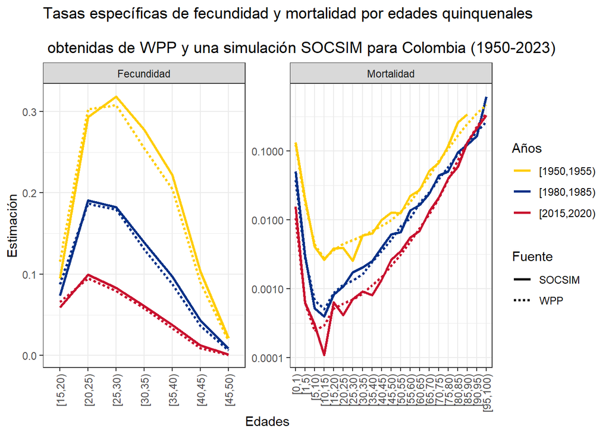

```r
## Graficar las tasas específicas de fecundidad y mortalidad SOCSIM vs WPP
bind_rows(WPP_fert %>% rename(Estimate = ASFR),
          SocsimF %>% rename(Estimate = ASFR)) %>%
  mutate(Sex = "Female") %>%
  bind_rows(WPP_mort %>% rename(Estimate = mx),
            SocsimM %>% rename(Estimate = mx)) %>%
  # Filtrar las tasas de valores 0, infinito (N_Muertes/0_Población) y NaN (0_Muertes/0_Población)
  filter(Estimate != 0 & !is.infinite(Estimate) & !is.nan(Estimate)) %>%
  filter(Sex == "Female") %>%
  mutate(age = factor(as.character(age), levels = age_levels)) %>%
  filter(year %in% yrs_plot) %>%
  ggplot(aes(x = age, y = Estimate, group = interaction(year, Source)))+
  facet_wrap(. ~ Rate, scales = "free") +
  geom_line(aes(colour = year, linetype = Source), linewidth = 1)+
  scale_linetype_manual(values = c("WPP" = "11","SOCSIM" = "solid")) +
  facetted_pos_scales(y = list(ASFR = scale_y_continuous(),
                               ASMR =  scale_y_continuous(trans = "log10")))+
  scale_x_discrete(guide = guide_axis(angle = 90)) +
  scale_color_manual(values = c("#FFCD00", "#003087", "#C8102E"))+
  labs(title = "Tasas específicas de fecundidad y mortalidad por edades quinquenales
       \n obtenidas de WPP y una simulación SOCSIM para Colombia (1950-2023)",
       x = "Edades", y = "Estimación",
       color = "Años", linetype = "Fuente") +
  theme_bw()
```

En términos generales, las tasas de fecundidad y mortalidad por edades quinquenales derivadas de la microsimulación se aproximan a las tasas originales de WPP2024 utilizadas como datos de entrada, lo que nos permite considerar los resultados como suficientemente validos para el analisis. No obstante, es posible observar algunas diferencias entre ambas fuentes que pueden reducirse al incrementar el tamaño de la poblacion inicial.

#### 3. ¿Qué se puede hacer con los resultados de la simulación? Ejemplo: estimaciones de pérdida y disponibilidad de parientes

> Preparado por Mallika Snyder, https://twitter.com/mallika_snyder, para el taller SOCSIM realizado en PAA 2023

Objetivos

1. Aprender a analizar los resultados de una simulación SOCSIM
2. Comprender cómo SOCSIM registra los vínculos familiares
3. Utilizar los resultados de SOCSIM de la sección anterior para estimar los niveles de pérdida (y disponibilidad) de parientes en Colombia.

Después de correr nuestra simulación, SOCSIM nos proporciona una genealogía sintética para toda la población. Sabemos cuándo nacen las personas, cuándo mueren, cuándo se casan y quiénes son sus padres y su cónyuge. ¿Qué podemos hacer con esta información?

Una de las ventajas de utilizar una herramienta como SOCSIM es que podemos identificar redes de parentesco extensas, especialmente en el caso de parientes más lejanos que serían difíciles de relacionar mediante un censo o una encuesta de hogares. Por ejemplo, ¿qué tan sencillo sería identificar a la bisabuela de un individuo en una encuesta de hogares, suponiendo que las probabilidades de corresidencia no sean altas? Por supuesto, algunos tipos de parientes son más fáciles de identificar que otros, basándonos en la información que tenemos en SOCSIM. Al identificar a los parientes, utilizamos relaciones de parentesco por consanguinidad directa -como padres e hijos- y afinidad -como cónyuges-. Este es el principio en el que se basa la función `retrieve_kin()` incluida en `rsocsim` que puede utilizarse para identificar parientes de diversos tipos (padres, hijos, abuelos, hermanos, cónyuges, y mucho más). Puedes leer la documentación completa de esta función escribiendo `?retrieve_kin` en la consola de RStudio. Un aspecto importante es que los términos de parentesco utilizados en esta función son principalmente validos para “occidente”; otras regiones pueden tener sistemas de parentesco diferentes, lo que puede influir en la disponibilidad de parientes.

Además de permitirnos identificar más fácilmente las redes de parentesco, SOCSIM también nos proporciona información valiosa sobre la cronología de los eventos vitales, como nacimientos, muertes y matrimonios, en estas redes. Esto puede ayudarnos a relacionar los cambios en las tasas demográficas con los cambios en las redes de parentesco disponibles para nuestras personas simuladas, a menudo a un nivel temporal muy preciso (meses o años). En este taller nos centraremos en un solo ejemplo -la pérdida de parientes-, pero hay muchas más formas posibles de utilizar SOCSIM para estudiar éstas y otras cuestiones sobre las dinámicas de parentesco.

En investigaciones anteriores, SOCSIM ha sido especialmente apropiado para estudiar la pérdida de parientes con relación al cambio en la mortalidad (Zagheni 2011; Verdery et al. 2020; Snyder et al. 2022). Aquí nos centraremos en un ejemplo sencillo: los cambios en la tasa de experimentar la pérdida de un familiar a lo largo del tiempo. Utilizaremos como grupo de referencia a las mujeres de entre 25 y 39 años que están vivas en un año determinado. Así, la muestra cambiará cada año. El denominador incluye a todas las mujeres, no sólo a las que tienen un familiar vivo.

Para esto, en nuestro código, utilizaremos una función que ejecutaremos en bucle para cada año de interés. La función tomará un año, buscará los individuos (mujeres) de la edad correspondiente que estén vivos ese año, identificará los años de fallecimiento de sus familiares y, a continuación, calculará la proporción de nuestra muestra que experimentó una pérdida. También calcularemos la proporción de mujeres que tuvieron un familiar vivo el año anterior. El código es una versión simplificada de las funciones utilizadas en un trabajo de investigación anterior (Snyder et al. 2022).

##### 3.1. Estimar la pérdida de parientes

Lo primero que necesitamos es una función de ayuda para identificar el año de interés. Esta función está incluida internamente en algunas funciones del paquete `rsocsim`, pero la utilizaremos aquí para convertir nuestras fechas mensuales en anuales.

```r
# Esta función utiliza el año final de simulación (enero-diciembre) y el último mes simulado para convertir los meses SOCSIM en años calendario
asYr <- function(month, last_month=last_month, final_sim_year=final_sim_year) {
  return(final_sim_year - trunc((last_month - month)/12))
}
```

También necesitamos definir algunos parámetros específicos para esta simulación y crear algunas variables.

```r
# Último mes simulado
last_month <- max(opop$dob)
# Último año simulado
final_sim_year <- 2023

# Organizar nuestro archivo de población
opop <- opop %>%
  # Fijar las fechas de defunción para los individuos que aún viven al final de la simulación
  mutate(dod = if_else(dod == 0, last_month, dod)) %>%
  # Fechas de nacimiento y defunción en años
  mutate(dob_year = asYr(dob, last_month=last_month, final_sim_year=final_sim_year),
         dod_year = asYr(dod, last_month=last_month, final_sim_year=final_sim_year))
```

Ahora que hemos generado las variables necesarias, crearemos una función sencilla `getKinLoss()` para estimar la pérdida anual de parientes de las mujeres de 25 a 39 años en un año concreto que podemos ejecutar en bucle durante el periodo de estudio.

```r
# Estimar la pérdida anual de parientes de las mujeres de 25 a 39 años en un año concreto
getKinLoss <- function(year_of_interest, opop = opop, omar = omar){

pid_data <- opop %>%
  # Eliminar a los individuos que no están vivos en el año de interés
  filter(data.table::between(lower = dob_year, upper = dod_year,
                             year_of_interest, incbounds = FALSE),
  # Filtrar solo a las mujeres
         fem == 1) %>%
  # Estimar la edad de las mujeres vivas en el año de interés
  mutate(age = year_of_interest - dob_year) %>%
  # Filtrar a las mujeres de 25 a 39 años
  filter(data.table::between(lower = 25, upper = 39, age,
                             incbounds = TRUE))
# Encontrar el vector de ID de persona
pid_vec <- pid_data$pid

# Usar la función retrieve_kin() incluida en `rsocsim`
# No identificaremos relaciones de parentesco extendidas (extra_kintypes),
# ni separaremos los parentescos por sexo, pero ambos pueden estimarse
kin <- rsocsim::retrieve_kin(opop = opop, omar = omar, pid = pid_vec,
             extra_kintypes = NULL, kin_by_sex = FALSE)

# Usando retrieve_kin, obtenemos una lista de listas (kin) nombradas según el tipo de pariente

# Ejecutar bucle para todos los tipos de parientes identificados anteriormente
temp <- bind_rows(lapply(1:length(kin), function(x) {
# Buscar los ID de los parientes
kin2 <- unlist(kin[[x]], use.names = FALSE)
# Adjuntar los ID de las personas
names(kin2) <- rep(pid_vec, unlist(lapply(kin[[x]], length)))
# Identificar los años de nacimiento de los parientes
attr(kin2, "kin_dob_year") <- opop$dob_year[match(kin2, opop$pid)]
# Identificar los años de defunción de los parientes
attr(kin2, "kin_dod_year") <- opop$dod_year[match(kin2, opop$pid)]
# Identificar qué parientes estaban vivos el año anterior
attr(kin2, "kin_alive_before_year_of_interest") <-
  if_else(data.table::between(lower = attr(kin2, "kin_dob_year"),
                              upper = attr(kin2, "kin_dod_year"),
                             (year_of_interest-1), NAbounds = NA,
                             incbounds = FALSE),
          TRUE, FALSE)
# Identificar qué parientes han muerto en el año de interés
attr(kin2, "kin_death_year_of_interest") <-
  if_else(attr(kin2, "kin_dod_year") %in% year_of_interest, TRUE, FALSE)

# Calcular el número de individuos que tenían un familiar vivo el año anterior
pid_withkin <- length(unique(names(kin2[attr(kin2,
                                          "kin_alive_before_year_of_interest")
                                        == TRUE])))

# Calcular el número de individuos que han perdido a un familiar
pid_losekin <- length(unique(names(kin2[attr(kin2, "kin_death_year_of_interest")
                                        == TRUE])))
# Calcular el número total de individuos
pid_total <- length(pid_vec)

# Generar la información de salida como un tibble
output <- tibble(kintype = names(kin[x]),
                 year = year_of_interest,
                 n_total = pid_total,
                 n_losekin = pid_losekin,
                 n_withkin = pid_withkin,
                 pc_losekin_total = 100*(n_losekin/n_total),
                 pc_withkin = 100*(n_withkin/n_total))
return(output)
}))
}
```

Ahora ejecutemos esta función sobre el periodo de estudio para generar una tabla con los datos de cada año. Para limitar el tiempo de ejecución del código, estimaremos la pérdida de parientes en intervalos de 10 años entre 1950 y 2020.

```r
# Ejecutar bucle sobre el rango de años y combinar las filas
kinloss_data <- bind_rows(lapply(seq.int(from = 1950, to = 2020, by = 10),
                              function(x) getKinLoss(year_of_interest = x,
                                                     opop = opop,
                                                     omar = omar)))
```

##### 3.2. Examinar nuestras estimaciones

```r
# Especificar y ordenar los nombres de los parientes
kinloss_data <- kinloss_data %>%
  mutate(kintype = case_when(kintype == "ggparents" ~ "Bisabuelos",
                             kintype == "gparents" ~ "Abuelos",
                             kintype == "parents" ~ "Padres",
                             kintype == "siblings" ~ "Hermanos",
                             kintype == "spouse" ~ "cónyuges",
                             kintype == "children" ~ "Hijos",
                             kintype == "gchildren" ~ "Nietos",
                             TRUE ~ kintype),
         kintype = fct_relevel(kintype, c("Bisabuelos", "Abuelos", "Padres",
                                          "Hermanos", "cónyuges", "Hijos", "Nietos")))
```

Graficar la pérdida y disponibilidad de parientes para la población femenina a lo largo del tiempo.

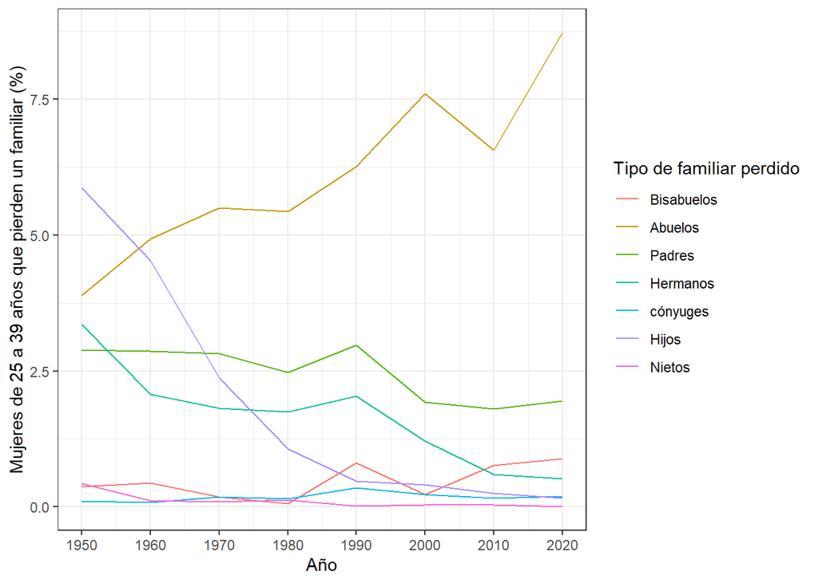

```r
# Graficar la pérdida de parientes
kinloss_data %>%
  ggplot(aes(x = year, y = pc_losekin_total, color = kintype)) +
  geom_line() +
  labs(x = "Año", y = "Mujeres de 25 a 39 años que pierden un familiar (%)",
       color = "Tipo de familiar perdido") +
  scale_x_continuous(breaks = seq(1950, 2020,by = 10))+
  theme_bw()
```

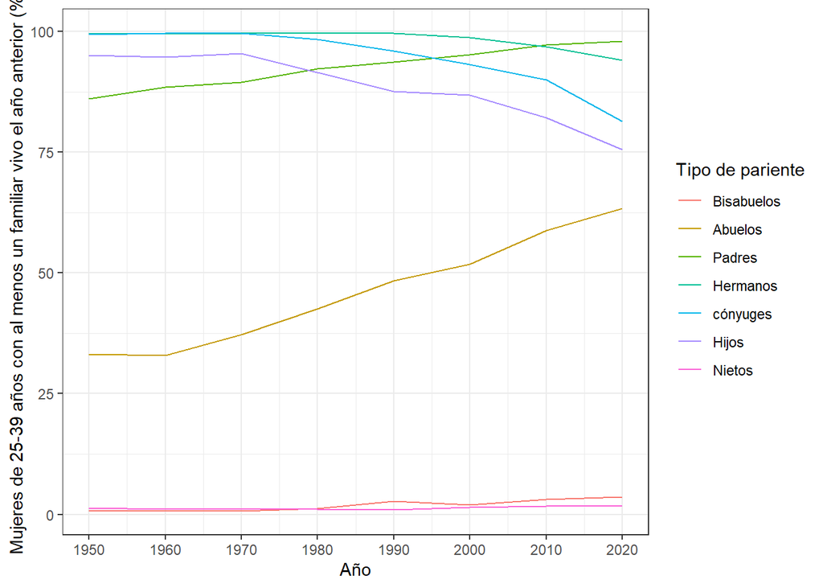

```r
# Graficar la disponibilidad de parientes
kinloss_data %>%
  ggplot(aes(x = year, y = pc_withkin, color = kintype)) +
  geom_line() +
  labs(x = "Año", y = "Mujeres de 25-39 años con al menos un familiar vivo el año anterior (%)",
       color = "Tipo de pariente") +
  scale_x_continuous(breaks = seq(1950, 2020,by = 10))+
  theme_bw()
```

En efecto, los abuelos y, en menor medida, los padres son los parientes que han mostrado un aumento significativo de su disponibilidad en las últimas décadas. Por el contrario, los hijos, cónyuges y ligeramente los hermanos han mostrado una disminución, probablemente relacionada con la reducción de la fecundidad y la nupcialidad.

#### 4. Más información

El manual ‘SOCSIM Oversimplified’ escrito por Carl Mason Mason (2016) es un gran punto de partida para aprender más sobre cómo funciona SOCSIM: https://lab.demog.berkeley.edu/socsim/CurrentDocs/socsimOversimplified.pdf. Puedes encontrar más información sobre `rsocsim` en el sitio web del paquete: https://mpidr.github.io/rsocsim/, incluida la documentación de las funciones actualmente disponibles y el trabajo en curso.

Estamos trabajando en la preparación de viñetas ampliadas con ejercicios y ejemplos para utilizar `rsocsim`. Síguenos en X para estar al día. Pónte también en contacto con nosotros si deseas utilizar `rsocsim` para tu trabajo. ¡Queremos saber de tí!

#### 5. Agradecimientos

Este tutorial es una versión modificada del taller “Demographic microsimulations in R using SOCSIM: Modelling population and kinship dynamics” organizado por el Panel de Demografía Digital y Computacional de la IUSSP y el Instituto Max Planck para la Investigación Demográfica (MPIDR), el 12 de abril de 2023 en Nueva Orleans, Estados Unidos, como parte de la Reunión Anual 2023 de la Asociación Americana de Población (PAA). Para más detalles, véase: https://github.com/alburezg/rsocsim_workshop_paa.

El material reune las contribuciones de los organizadores del taller presentado en PAA 2023:

- Tom Theile: https://twitter.com/TheileTom
- Diego Alburez-Gutierrez: https://twitter.com/d_alburez
- Liliana P. Calderón-Bernal: https://twitter.com/lp_calderonb
- Mallika Snyder: https://twitter.com/mallika_snyder
- Emilio Zagheni: https://twitter.com/ezagheni

## DemoKin

#### Introducción a los modelos matriciales de parentesco en R utilizando DemoKin

Pronto comenzaremos las sesiones de laboratorio informático, por lo que sería estupendo haber preparado de antemano el entorno R. En primer lugar, necesitarás R y Rstudio instalados. Segundo, ¡instala el DemoKin!

[figure not shown]

- Instalación
- Modelo variable en el tiempo: un sexo
- Modelo variable en el tiempo: dos sexos
- Enfoque por periodo
- ¿Qué más?
- Ejercicio

#### 1. Instalación

Instala la versión en desarrollo.

```r
#Install the development version from GitHub

# install.packages("devtools")
# devtools::install_github("IvanWilli/DemoKin")
```

Otros paquetes serán útiles. Encárgate de tenerlos instalados:

```r
# con esto puedes asegurarte de tenerlos todos instalados
# packages_needed <- c("dplyr", "tidyr", "ggplot2", "data.table", "readr")
# packages_needed_nothaving <- packages_needed[!packages_needed %in% installed.packages()]
# for(lib in packages_needed_nothaving) install.packages(lib,dependencies=TRUE)

# actívalos
library(DemoKin)
library(dplyr)
library(tidyr)
library(ggplot2)
library(data.table)
library(readr)
```

#### 2. Modelo variable en el tiempo: un sexo

Las tasas demográficas cambian cada año, lo que significa que Ego (o Focal) y sus parientes habrán experimentado tasas de mortalidad y fecundidad cambiantes a lo largo del tiempo. Empezaremos a construir las estructuras de parentesco en un modelo variable en el tiempo de un sexo, donde Ego es mujer, por lo que utiloizaremos sólo tasas de población femeninas.

Podemos acceder a las tasas demográficas de cualquier país del mundo, elaboradas por el proyecto World Population Prospects (WPP) de Naciones Unidas. En los ejemplos utilizaremos los datos de fecundidad, mortalidad y población de Colombia desde 1950 hasta 2023. En la carpeta de datos también encontrarás datos de Argentina, Brasil y México para el mismo período.

Carguemos primero los datos para las mujeres en Colombia de 1950 a 2023

```r
#Load data

col_female <- read_csv("data/col_female.csv") #female rates
col_popfemale <- read_csv("data/col_popfemale.csv") #female population (N)
```

Aquí, trazamos $q_x$ (complemento de $p_x$) sobre la edad y el tiempo:

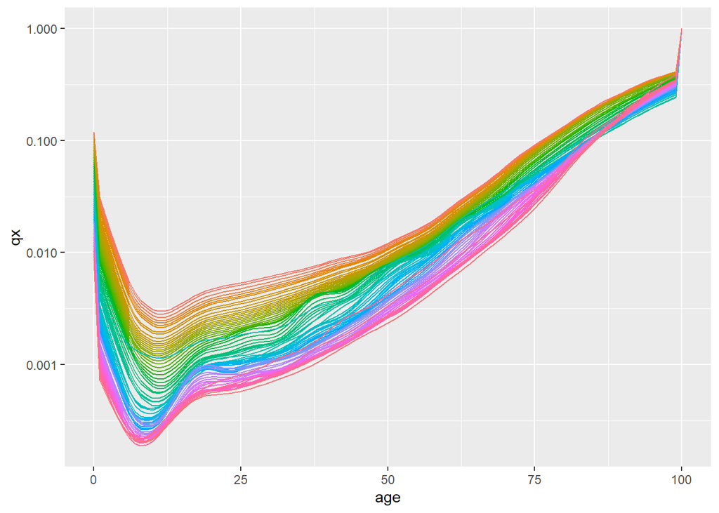

```r
col_female %>%
    mutate(qx = 1-px) %>%
    ggplot() +
    geom_line(aes(x = age, y = qx, col = factor(year))) +
    scale_y_log10() +
    theme(legend.position = "none")
```

Tasas de fecundidad por edades:

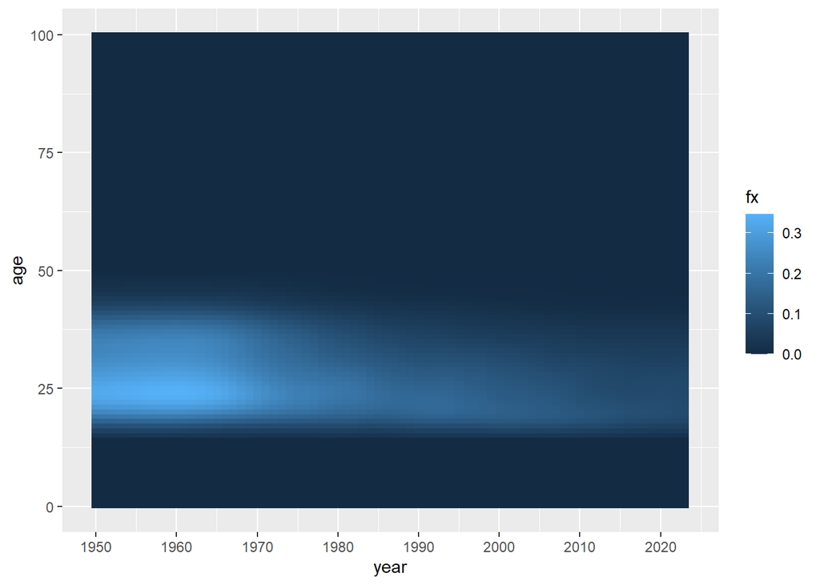

```r
col_female %>%
     ggplot() + geom_tile(aes(x = year, y = age, fill = fx)) +
     scale_x_continuous(breaks = seq(1900,2020,10), labels = seq(1900,2020,10))
```

Con esta información podemos modelar la estructura de parentesco en dimensiones Edad-Periodo-Cohorte (APC):

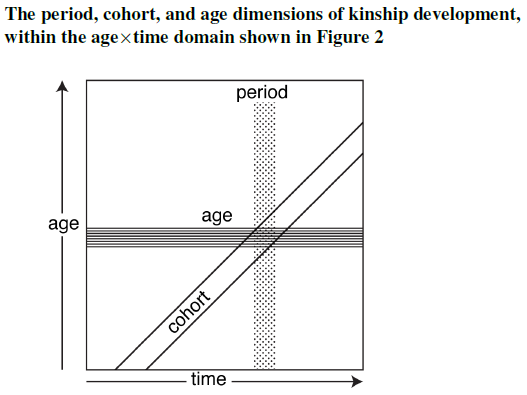

Caswell (2019)

En el caso de la población ya tenemos un formato de matriz que pueda utilizar DemoKin (es decir, crear una matriz con los años como columnas y las edades como filas). Tenemos que hacerlo para la fecundidad y la mortalidad:

```r
# Reshape fertility
col_asfr <- col_female %>%
  select(age, year, fx) %>%
  pivot_wider(names_from = year, values_from = fx) %>%
  select(-age) %>%
  as.matrix()

# Reshape survival
col_px_female <- col_female %>%
  select(age, year, px) %>%
  pivot_wider(names_from = year, values_from = px) %>%
  select(-age) %>%
  as.matrix()
```

Ahora sí! Los datos que estamos utilizando tienen años en columnas y edades en filas.

##### 2.1 La función `kin()`

La función `DemoKin` se puede utilizar para calcular el número y la distribución de edad de los parientes de Focal bajo una serie de supuestos, brindando la cantidad de parientes vivos y fallecidos. La función `DemoKin::kin()` realiza actualmente la mayor parte del trabajo en términos de implementación de modelos matriciales de parentesco.

Argumentos en un entorno variable en el tiempo:

1. *p* numérico. Un vector (atómico) o matriz de probabilidades de sobrevivencia con filas como edades (y columnas como años en caso de matriz).
2. *f* numérico. Igual que *p* pero para las tasas de fecundidad.
3. *n* numeric. Sólo para *time_invariant* = `FALSE`. Para la distribución de la población.
4. *time_invariant* logical. Suponemos tasas variables en el tiempo, entonces será `FALSE`.
5. *output_cohort* integer. Vector de cohortes de años para devolver los resultados. Debe estar dentro del intervalo de años de los datos de entrada.
6. *output_period* entero. Igual que output_cohort, pero vector de años del periodo para devolver resultados.
7. *output_kin* carácter. Tipos de parentesco a devolver: `m` para madre, `d` para hija, … Puedes ver el resto de código en `DemoKin::demokin_codes`, en este casos la columna *Labels_female* será la referencia.

Pongámosla en acción…

##### 2.2 Enfoque de cohorte

Ahora ejecutemos un modelo dinámico de parentesco de un sexo, obteniendo la cohorte de 1993 (tarda unos segundos):

```r
col_1993 <-
  kin(p = col_px_female,
      f = col_asfr,
      n = col_popfemale,
      time_invariant = FALSE,
      output_cohort = 1993,
      output_kin = c("d", "m", "gm", "c", "a", "s"))
```

Los parientes para el argumento `output_kin` se identifican mediante un código único. Seleccionamos seis parientes para explorar en este workskop: hijas (d), madres (m), abuelas (gm), primas (c), tías (a) y hermanos (s). La equivalencia entre los dos conjuntos de códigos figura en la tabla siguiente:

```r
demokin_codes
```

```
##    DemoKin Caswell               Labels_female                   Labels_male
## 1      coa       t    Cousins from older aunts     Cousins from older uncles
## 2      cya       v  Cousins from younger aunts   Cousins from younger uncles
## 3        c    <NA>                     Cousins                       Cousins
## 4        d       a                   Daughters                          Sons
## 5       gd       b             Grand-daughters                    Grand-sons
## 6      ggd       c       Great-grand-daughters              Great-grand-sons
## 7      ggm       h          Great-grandmothers            Great-grandfathers
## 8       gm       g                Grandmothers                  Grandfathers
## 9        m       d                      Mother                        Father
## 10     nos       p   Nieces from older sisters   Nephews from older brothers
## 11     nys       q Nieces from younger sisters Nephews from younger brothers
## 12       n    <NA>                      Nieces                       Nephews
## 13      oa       r     Aunts older than mother     Uncles older than fathers
## 14      ya       s   Aunts younger than mother    Uncles younger than father
```

[output cut: 23 more lines]

##### 2.3 Diagrama de parentesco de Keyfitz

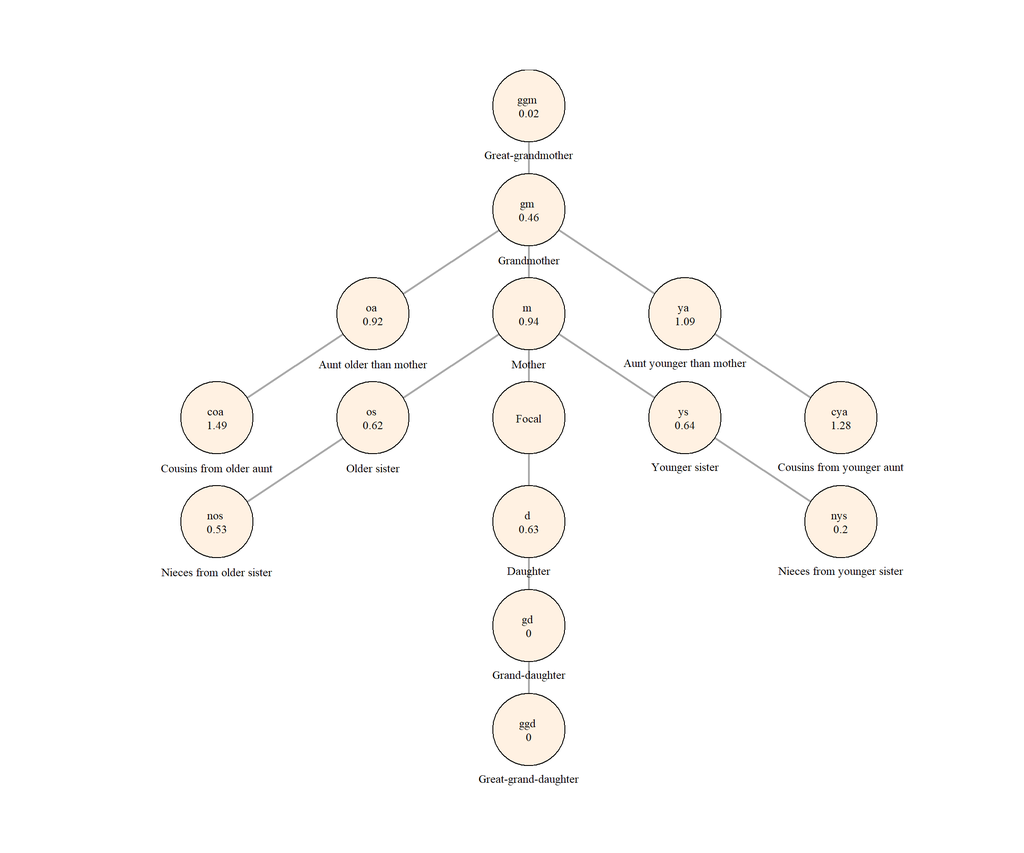

```r
col_1993_full <-
  kin(p = col_px_female,
      f = col_asfr,
      n = col_popfemale,
      time_invariant = FALSE,
      output_cohort = 1993)

col_1993_full$kin_summary %>%
  filter(age_focal == 30) %>%
  select(kin, count = count_living) %>%
  plot_diagram(rounding = 2)
```

¿Qupe significa tener 0.94 madres?

##### 2.4 Parientes vivos

Ahora, visualicemos cómo cambia el número esperado de hijas, hermanas, primas, etc., a lo largo de la vida de Focal.

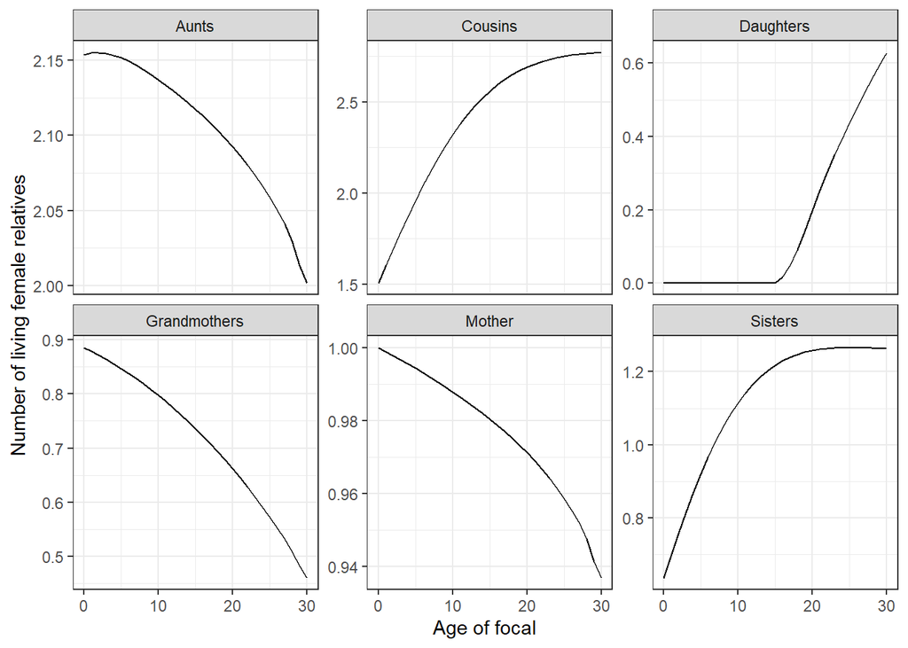

```r
col_1993$kin_summary %>%
  rename_kin() %>%
  ggplot() +
  geom_line(aes(age_focal, count_living))  +
  theme_bw() +
  labs(x = "Age of focal", y= "Number of living female relatives") +
  facet_wrap(~kin_label, scales = "free_y")
```

En el gráfico anterior podemos ver el número de parientes mujeres vivos para la cohorte nacida en 1993. Antes de profundizar en la estructura de parentesco de Colombia, añadamos los parientes masculinos.

#### 3. Modelo variable en el tiempo: dos sexos

En general, los hombres viven menos y se reproducen más tarde que las mujeres. Estos procesos específicos de cada sexo afectan la dinámica del parentesco de varias maneras. Por ejemplo, las chances que Focal tenga un abuelo vivo se ve afectado por la mortalidad diferencial en edades más avanzadas, diferente al caso de abuelas. También nos puede interesar estudiar cómo varían las estructuras de parentesco según el sexo del Focal: un Focal varón puede tener un número diferente de nietos que una Focal mujer, dadas las diferencias de fecundidad por sexo. Documentar estas diferencias es importante, ya que por ejemplo las tareas familiares de apoyo y cuidados informales a la red familiar no es pareja por sexo en nuestros países.

Vayamos en ese sentido entonces. La función `kin2sex` implementa un modelo de parentesco de dos sexos. Es similar a la función de un sexo `kin` (ver `?kin`) con dos excepciones. En primer lugar, el usuario necesita especificar la mortalidad y la fecundidad por sexo. En segundo lugar, necesita indicar el sexo de Focal (que se supone femenino por defecto, como en el modelo de un solo sexo).

Dado que disponemos de la sobrevivencia y la población masculinas en el proyecto World Population Prospects (WPP), podemos contar con estos datos.

```r
#Load data

col_male <- read_csv("data/col_male.csv") # male rates
col_popmale <- read_csv("data/col_popmale.csv") # male population (N)
```

Tenemos que remodelar la mortalidad para crear una matriz que pueda utilizar `DemoKin` (es decir, crear una matriz con los años como columnas y las edades como filas), tal como hicimos antes:

```r
# Reshape survival

col_px_male <- col_male %>%
  select(age, year, px) %>%
  pivot_wider(names_from = year, values_from = px) %>%
  select(-age) %>%
  as.matrix()
```

Sin embargo, ¿para cuántos países se dispone de información sobre la fecundidad masculina? Dado que no tenemos información sobre la fecundidad masculina a lo largo del tiempo para Colombia, utilizaremos el supuesto andrógino de que los hombres y las mujeres tienen las mismas tasas de fecundidad.

```r
col_2sex_1993 <- kin2sex(
  pf = col_px_female,
  pm = col_px_male,
  ff = col_asfr,
  fm = col_asfr,
  nf = col_popfemale,
  nm = col_popmale,
  time_invariant = FALSE,
  output_cohort = 1993,
  output_kin = c("d", "m", "gm", "c", "a", "s"),
  sex_focal = "f",
  birth_female = .5)
```

La salida de `kin2sex` es equivalente a la de `kin`, salvo que incluye una columna `sex_kin` para especificar el sexo de los familiares dados. Eche un vistazo con `head(col_kin_2sex$kin_summary)`.

```r
head(col_2sex_1993$kin_summary)
```

```
## # A tibble: 6 × 10
##   age_focal kin   sex_kin cohort count_living mean_age sd_age count_dead
##       <int> <chr> <chr>    <int>        <dbl>    <dbl>  <dbl>      <dbl>
## 1         0 a     f         1993         4.39    25.3   10.4     0.00579
## 2         0 a     m         1993         4.21    25.0   10.4     0.0206
## 3         0 c     f         1993         6.13     9.54   7.55    0.0145
## 4         0 c     m         1993         6.05     9.46   7.50    0.0230
## 5         0 d     f         1993         0      NaN    NaN       0
## 6         0 d     m         1993         0      NaN    NaN       0
## # ℹ 2 more variables: count_cum_dead <dbl>, mean_age_lost <dbl>
```

> Una nota sobre terminología: La función `kin2sex` utiliza los mismos códigos que `kin` para identificar a los parientes (véase `demokin_codes()`). Tenga en cuenta que cuando se ejecuta un modelo de dos sexos, ¡el código «m» se refiere a madres o padres! Utilice la columna `sex_kin` para filtrar el sexo de un pariente determinado. Por ejemplo, para considerar sólo a los hijos e ignorar a las hijas, utilice:

```r
col_2sex_1993$kin_summary %>%
  filter(kin == "d", sex_kin == "m") %>%
  head()
```

```
## # A tibble: 6 × 10
##   age_focal kin   sex_kin cohort count_living mean_age sd_age count_dead
##       <int> <chr> <chr>    <int>        <dbl>    <dbl>  <dbl>      <dbl>
## 1         0 d     m         1993            0      NaN    NaN          0
## 2         1 d     m         1993            0      NaN    NaN          0
## 3         2 d     m         1993            0      NaN    NaN          0
## 4         3 d     m         1993            0      NaN    NaN          0
## 5         4 d     m         1993            0      NaN    NaN          0
## 6         5 d     m         1993            0      NaN    NaN          0
## # ℹ 2 more variables: count_cum_dead <dbl>, mean_age_lost <dbl>
```

##### 3.1 Parientes vivos

Ahora podemos visualizar cómo es el número esperado de parientes vivos según el sexo y la edad de Focal. ¿Qué podemos ver para esta cohorte?

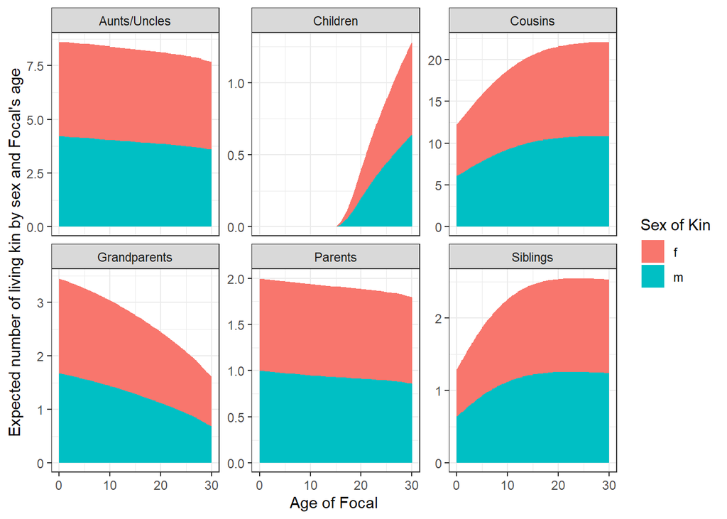

```r
  col_2sex_1993$kin_summary %>%
  rename_kin(sex = "2sex") %>%
  summarise(count=sum(count_living), .by = c(kin_label, age_focal, sex_kin)) %>%
  ggplot(aes(age_focal, count, fill=sex_kin)) +
  geom_area() +
  theme_bw() +
  labs(y = "Expected number of living kin by sex and Focal's age",
       x = "Age of Focal",
       fill = "Sex of Kin") +
  facet_wrap(~kin_label, scales = "free_y")
```

##### 3.2 Muerte de parientes

La pérdida de familiares tiene graves consecuencias para los familiares en duelo, ya que puede afect por ejemplo a la prestación de apoyo asistencial y a las transferencias intergeneracionales a lo largo de la vida. El objeto de salida `kin_summary` proporciona información sobre el número de familiares perdidos por Focal durante su vida (acumulado), almacenada en la columna `count_cum_death`. El gráfico siguiente compara los patrones de pérdida acumulada de parientes para la cohorte de 1993 (30 años en 2023) por sexo del pariente.

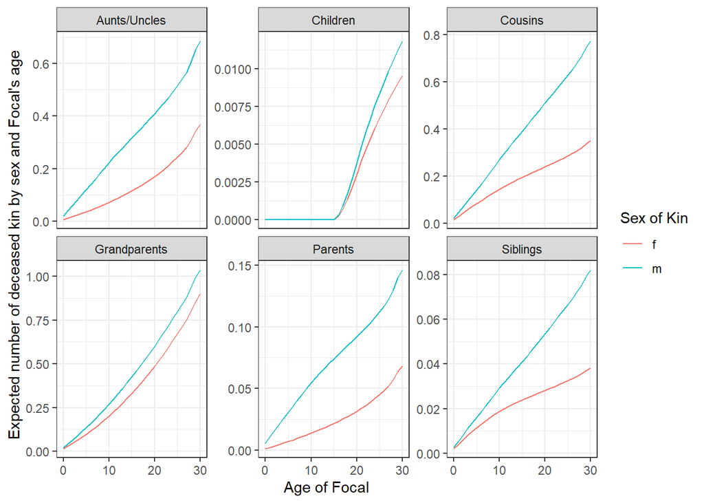

```r
col_2sex_1993$kin_summary %>%
  rename_kin(sex = "2sex") %>%
  summarise(count=sum(count_cum_dead), .by = c(kin_label, sex_kin, age_focal)) %>%
  ggplot(aes(age_focal, count, col=sex_kin))+
  geom_line()+
  theme_bw() +
  labs(y = "Expected number of deceased kin by sex and Focal's age",
       x = "Age of Focal",
       col = "Sex of Kin") +
  facet_wrap(~kin_label, scales = "free_y")
```

##### 3.3 Proporción de sexos

La información sobre la disponibilidad de parientes por sexo nos permite investigar la disponibilidad según sexo a diferentes edades de focal. Una medida tradicional en demografía es el índice de masculinidad, con los hombres en el numerador y las mujeres en el denominador. La siguiente figura, por ejemplo, muestra que una mujer colombiana de 30 años en 2023 puede esperar tener 0.75 abuelos por cada abuela. ¿Es siempre cierto que la proporción de sexos disminuirá a la edad de Focal?

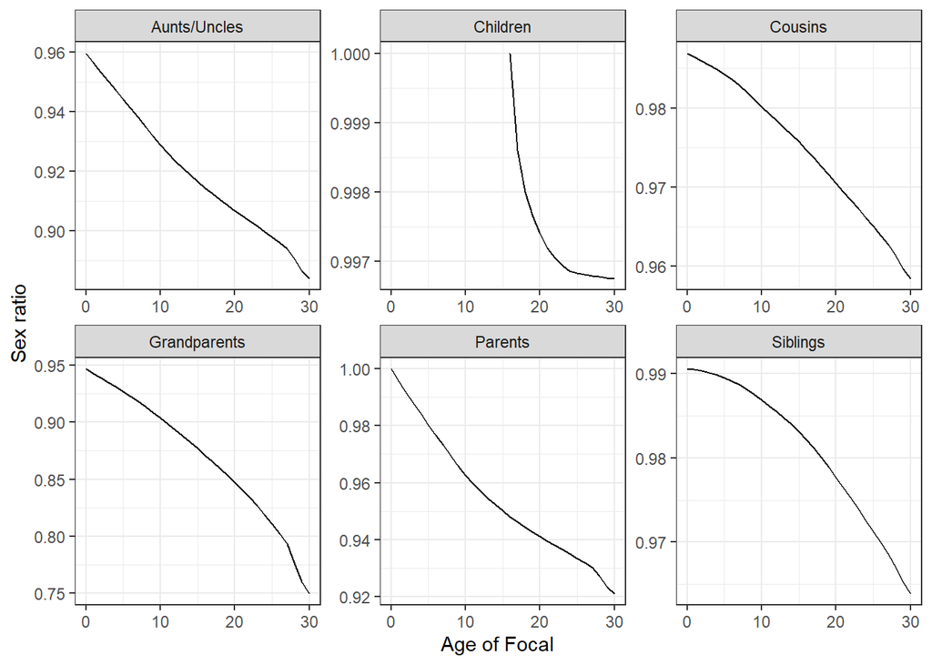

```r
col_2sex_1993$kin_summary %>%
  rename_kin(sex = "2sex") %>%
  group_by(kin_label, age_focal) %>%
  summarise(sex_ratio = sum(count_living[sex_kin=="m"], na.rm=T)/sum(count_living[sex_kin=="f"], na.rm=T)) %>%
  ggplot(aes(age_focal, sex_ratio))+
  geom_line()+
  theme_bw() +
  labs(y = "Sex ratio",
       x = "Age of Focal") +
  facet_wrap(~kin_label, scales = "free")
```

La experiencia de pérdida de parentesco para los focales depende de las diferencias de mortalidad entre sexos. Una mujer Focal empieza a perder a sus padres antes que a sus madres. Vemos un patrón ligeramente diferente para los abuelos, ya que la experiencia de Focal de la pérdida de abuelos depende de la disponibilidad inicial de abuelos (es decir, si el abuelo de Focal murió antes de su nacimiento, nunca experimentará su muerte).

#### 4. Enfoque por períodos

Hasta ahora hemos utilizado el parámetro `output_cohort`, en esta sección exploraremos el `output_period`. Quizás esté interesado en tomar una instantánea de la distribución de parientes en algún año, por ejemplo 2023. Puede hacerlo especificando el argumento `output_period = 2023`.

```r
col_2sex_2023 <- kin2sex(
  pf = col_px_female,
  pm = col_px_male,
  ff = col_asfr,
  fm = col_asfr,
  nf = col_popfemale,
  nm = col_popmale,
  time_invariant = FALSE,
  output_period = 2023,
  output_kin = c("d", "m", "gm", "c", "a", "s"),
  sex_focal = "f",
  birth_female = .5)
```

Tracemos el número esperado de parientes vivos por sexo y edad del Focal:

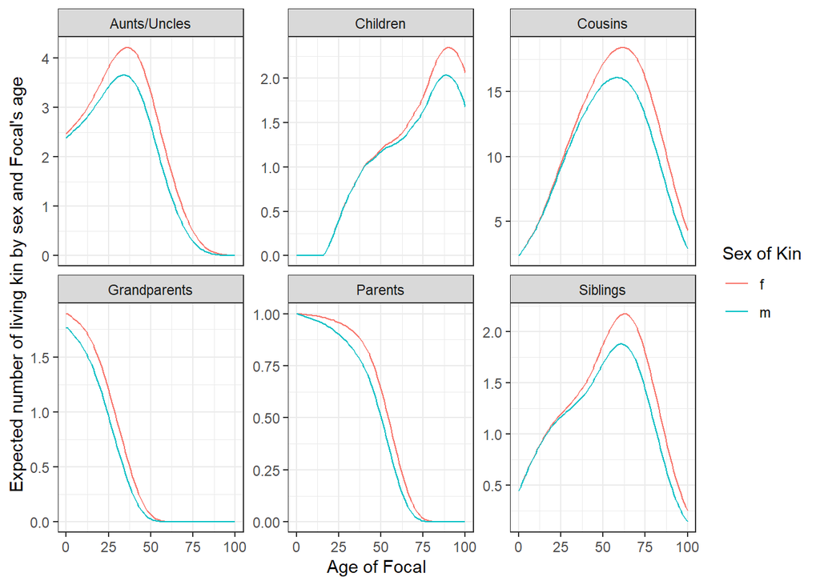

```r
col_2sex_2023$kin_summary %>%
  rename_kin(sex = "2sex") %>%
  ggplot(aes(age_focal, count_living, col=sex_kin)) +
  geom_line()+
  theme_bw() +
  labs(y = "Expected number of living kin by sex and Focal's age",
       x = "Age of Focal",
       col = "Sex of Kin") +
  facet_wrap(~kin_label, scales = "free_y")
```

¿Se parecen estos gráficos de «periodo» a los gráficos de «cohorte» mostrados anteriormente? ¿En qué casos preferiría un enfoque de período a uno de cohorte?

##### 4.1 A DemoKin no le gustan las combinaciones cohorte-período

> `DemoKin` sólo devolverá valores para periodos ó cohortes, pero nunca para combinaciones periodo-cohorte. Esto está relacionado con problemas de tiempo/memoria en los cálculos.

Considere el siguiente código, que dará un error ya que estamos pidiendo **tanto** una salida de cohorte como de período al mismo tiempo:

```r
kin2sex(
  pf = col_px_female,
  pm = col_px_male,
  ff = col_asfr,
  fm = col_asfr,
  nf = col_popfemale,
  nm = col_popmale,
  time_invariant = FALSE,
  output_cohort = 1963,
  output_period = 2023,
  sex_focal = "f",
  birth_female = .5)
```

```
## Error in kin2sex(pf = col_px_female, pm = col_px_male, ff = col_asfr, : sorry, you can not select cohort and period. Choose one please
```

#### 5. ¿Qué mas puedes hacer?

`DemoKin` tiene implementadas otras extensiones, gracias a la contribución de grandes colaboradores expertos en la temática:

- Análisis por causas de muerte, con la función `kin_time_variant_2sex_cod`.
- Análisis multi-estado, con la función `kin_multi_stage` (y testeando acutlamente una versión dinámica con dos sexos).

Si quieres meterte más en detalle en las funciones y la matemática que hay por detrás, puedes ver este curso: https://ivanwilli.github.io/matrix_kinship_course_lab/index.

#### 6. Ejercicio

Elija un país de la carpeta de datos (Argentina, Brasil o México). Utiliza los datos y las implementaciones vistas (1,2) para explorar una respuesta a las siguiente preguntas (abiertas):

- ¿Cuál es la relación entre la transición demográfica y la red de parentesco en este país?
- ¿Crees que podemos observar indicios de una «transición de parentesco»?

Recordemos que las implementaciones vistas son:

1 - Modelo variable en el tiempo: un sexo (enfoque de cohorte o período)

2 - Modelo variable en el tiempo: dos sexos (enfoque de cohorte o período)

## Descargar datos de otros países

¿Qué podemos hacer si queremos trabajar con otros países?

Mostraremos cómo seleccionar diferentes países y años, para aplicar lo aprendido en la sección rsocim y DemoKin.

Descargaremos los datos de fecundidad, mortalidad y población de todos los países desde 1950 hasta 2023.

En primer lugar, cargaremos la función `download_wpp24()`, que automatiza el proceso de descarga de estos datos. Tenga en cuenta que este proceso puede tardar un par de minutos.

Otros paquetes serán útiles.

```r
library(readr)
library(dplyr)
```

```r
# Load the function to download data
source("UNWPP_download.R")

# Download the data
download_wpp24()
```

```
## [1] "2024 World Population Prospects data downloaded and saved successfully as CSV files."
```

Una vez descargados los datos, podemos filtrar la información que nos interesa, por ejemplo, el país de interés. Para ello, cargaremos dos funciones:

- `UNWPP_data`: Esta función filtra los datos de mortalidad (px, qx, mx) y fecundidad (fx) por el país de interés y el periodo de tiempo correspondiente.
- `UNWPP_pop`: Esta función filtra los datos del tamaño de la población (N).

Para elegir el país de interés, puede consultar el nombre del país [aquí](https://unstats.un.org/unsd/methodology/m49/).

```r
# Load function to filter data
source("UNWPP_data.R")
```

```r
## Example output for rsocsim
# Select country, year and sex to obtain px,qx or mx

mortality_colombia <-
  UNWPP_data(country = "Colombia",
             start_year = 2023,
             end_year = 2023,
             indicators = c("px", "qx", "mx"), #indicators of interest
             output_format = "RData", #format you want to save (csv or Rdata)
             output_file = "mortality_colombia_example")

# Select country, year and sex to obtain fx

fertility_colombia <-
  UNWPP_data(country = "Colombia",
             start_year = 2023,
             end_year = 2023,
             indicators = "fx",
             output_format = "RData",
             output_file = "fertility_colombia_example")
```

```r
## Example output for DemoKin using female rates
# Select country, year and sex to obtain px and fx

argentina <-
  UNWPP_data(country = "Argentina",
             start_year = 2023,
             end_year = 2023,
             sex = "Female",
             indicators = c("px","fx"), #indicators of interest
             output_format = "csv", #format you want to save (csv or rdata)
             output_file = "argentina")
```

```r
## Example output for Demokin - population (N)
# Select country, year and sex to obtain N

pop_argentina <-
  UNWPP_pop(country = "Argentina",
            start_year = 2023,
            end_year = 2023,
            sex = "Female")
```

Recuerde que para DemoKin necesitamos remodelar la mortalidad y la fecundidad para ejecutar los modelos. Aquí un ejemplo de cómo hacerlo:

```r
# Reshape fertility
arg_asfr <- argentina %>%
  select(age, year, fx) %>%
  pivot_wider(names_from = year, values_from = fx) %>%
  select(-age) %>%
  as.matrix()

# Reshape survival
arg_px_female <- argentina %>%
  select(age, year, px.x) %>%
  pivot_wider(names_from = year, values_from = px.x) %>%
  select(-age) %>%
  as.matrix()
```

#### Referencias

Alburez‐Gutierrez, Diego, Carl Mason, and Emilio Zagheni. 2021. “The ‘Sandwich Generation’ Revisited: Global Demographic Drivers of Care Time Demands.” *Population and Development Review* 47 (4): 997–1023. https://doi.org/10.1111/padr.12436.

Hammel, E. A. 2005. “Demographic Dynamics and Kinship in Anthropological Populations.” *Proceedings of the National Academy of Sciences* 102 (6): 2248–53. https://doi.org/10.1073/pnas.0409762102.

Hammel, E., D Hutchinson, K Wachter, R Lundy, and R Deuel. 1976. *The SOCSIM Demographic-Sociological Microsimulation Program: Operating Manual*. Institute of International Studies. University of California Berkeley.

Margolis, Rachel, and Ashton M. Verdery. 2019. “A Cohort Perspective on the Demography of Grandparenthood: Past, Present, and Future Changes in Race and Sex Disparities in the United States.” *Demography* 56 (4): 1495–1518. https://doi.org/10.1007/s13524-019-00795-1.

Mason, Carl. 2016. “Socsim Oversimplified. Berkeley: Demography Lab, University of California.”

Snyder, Mallika, Diego Alburez-Gutierrez, Iván Williams, and Emilio Zagheni. 2022. “Estimates from 31 Countries Show the Significant Impact of COVID-19 Excess Mortality on the Incidence of Family Bereavement.” *Proceedings of the National Academy of Sciences* 119 (26): e2202686119. https://doi.org/10.1073/pnas.2202686119.

United Nations, Department of Economic, and Population Divisions Social Affairs. 2024. “World Population Prospects 2024: Methodology of the United Nations Population Estimates and Projections.”

Verdery, Ashton M., and Rachel Margolis. 2017. “Projections of White and Black Older Adults Without Living Kin in the United States, 2015 to 2060.” *Proceedings of the National Academy of Sciences* 114 (42): 11109–14. https://doi.org/10.1073/pnas.1710341114.

Verdery, Ashton M., Emily Smith-Greenaway, Rachel Margolis, and Jonathan Daw. 2020. “Tracking the Reach of COVID-19 Kin Loss with a Bereavement Multiplier Applied to the United States.” *Proceedings of the National Academy of Sciences* 117 (30): 17695. https://doi.org/10.1073/pnas.2007476117.

Wachter, Kenneth W. 2014. *Essential Demographic Methods*. Harvard University Press.

Wachter, Kenneth W. 1997. “Kinship Resources for the Elderly.” *Philosophical Transactions of the Royal Society of London. Series B: Biological Sciences* 352 (1363): 1811–17. https://doi.org/10.1098/rstb.1997.0166.

Zagheni, Emilio. 2011. “The Impact of the HIV/AIDS Epidemic on Kinship Resources for Orphans in Zimbabwe.” *Population and Development Review* 37 (4): 761–83. https://doi.org/10.1111/j.1728-4457.2011.00456.x.